# A Statistical Experiment on the Buttercup Data

Tonghui Xu (96973487)

25/05/2020

# Introduction

Giant buttercup is generally the most aggressive of the buttercups in New Zealand. Cattle will not eat the plant throughout most of the year which makes it much more of a problem on dairy farms. In dairy regions where giant buttercup exists, it can be a major problem. Such areas include Taranaki, Nelson Bays and near Woodville. The control of giant buttercup has never been particularly easy, many would think that use of herbicides would be the most effective way to get rid of this invasive weed, but this is not the case with the Giant Buttercup. There have been problems in some areas with biotypes of giant buttercup which have developed resistance to herbicides. An experiment was carried out to investigate the efficacy of different herbicides and management of pasture on the weed, giant buttercup (Ranunculus Acris), growth in dairy pastures. Two paddocks in each of nine farms were used for the experiment and in each paddock a randomized layout was used with eight herbicide treatments including a Nil control and plots mown, or not, before each grazing or not. There are two factors to be fitted (“Herbicide” and “Mow”) in the analysis. The measured variable for question 1 is the percent cover of buttercup in each plot (Buttercuppc). The measured variable for question 2 is the number of 10cm by 10cm squares of bare ground in each plot (BareGrnd). The plots were 10 metres by 2 metres so although there is a maximum value none of the observations approach this so we can approximate this variable as an unbounded count. There is a interaction term between Farm and Paddock. When we have the percent cover of buttercup in each plot, we fit a simple analysis of variance and a random effects model with fixed effect for both Mow and Herbicides and their interaction and a term for the Farm by Paddock interaction. When we have the number of 10cm by 10cm squares of bare ground in each plot (BareGrnd), we fit a a Generalised Linear model and a Generalised Linear mixed to the data with fixed effect for both Mow and Herbicide and their interaction and a random effect for the Farm by Paddock interaction.

# Question 1

# 1.

There are 864 random data collected in the original dataset. Two paddocks in each of nine farms were used for the experiment and in each paddock a randomized layout was used with eight herbicide treatments including a Nil control and plots mown, or not, before each grazing or not. So, Farm, Paddock, Herbicide and Mow are the predictive variables, and Buttercuppc are the response variable.

By inspecting the dataset, there are certainly some missing values. Before doing the further analysis, the missing values were removed from the dataset.

Exploratory data analysis was used to explore the dataset further. Boxplots were used as a graphical display of the variables to check for any extreme values, influential outliers, distribution of the variables and an overall insight of the data.

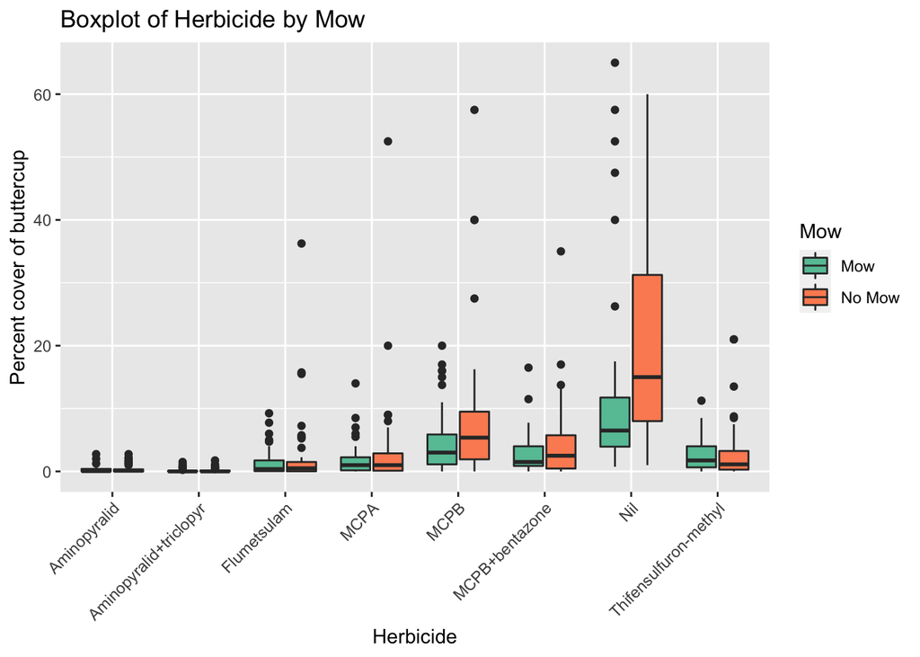

```r
buttercup <- read.csv("Buttercup Data.csv",header=T)
# remove NA
buttercup <- buttercup[complete.cases(buttercup),]
#attach(buttercup)
#View(buttercup)
# data exploratory
buttercup$Herbicide <- factor(buttercup$Herbicide)
buttercup$Mow <- factor(buttercup$Mow)
library(ggplot2)
library(RColorBrewer)
#boxplot for herbicide by mow
ggplot(buttercup, aes(x=Herbicide, y=Buttercuppc, fill=Mow)) +
  geom_boxplot() +
  labs(title="Boxplot of Herbicide by Mow",x="Herbicide", y="Percent cover of buttercup") +
  scale_fill_brewer(palette="Set2") +
  theme(text = element_text(size=11), axis.text.x = element_text(angle=45, hjust=1))
```

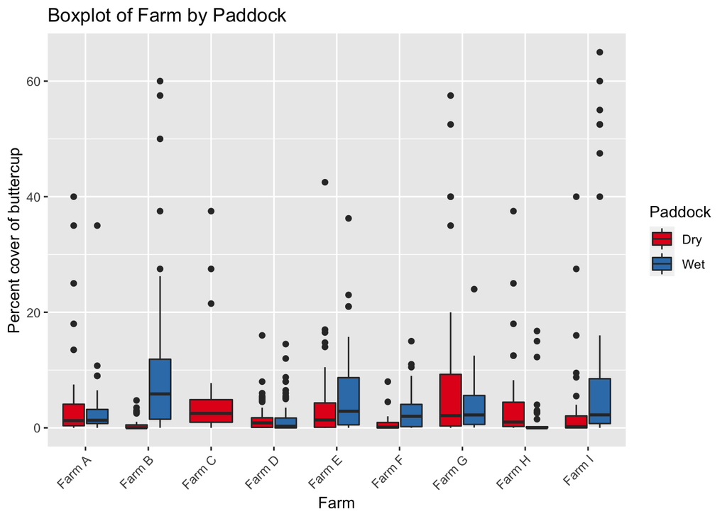

```r
#boxplot for farm by paddock
ggplot(buttercup, aes(x=Farm, y=Buttercuppc, fill=Paddock)) +
  geom_boxplot() +
  labs(title="Boxplot of Farm by Paddock",x="Farm", y="Percent cover of buttercup") +
  scale_fill_brewer(palette="Set1") +
  theme(text = element_text(size=11), axis.text.x = element_text(angle=45, hjust=1))
```

Boxplots of each herbicide by mow showed that the percent cover of buttercup in each plot was substantially higher where no herbicide was used. Plots treated with Aminopyralid+triclopyr and Aminopyralid alone showed lowest percent cover of buttercup. There does not seem to be an obvious trend in the boxplot whether the plot is mown or not. The percent cover of buttercup is higher when mown when certain herbicides are used and lower when mown when certain herbicides are used.

Boxplot of farm by paddock showed that the percent cover of buttercup didn’t vary much depending on the farm. There is no obvious pattern to which the buttercuppc was higher in dry or wet paddock.

# 2.

log-transformation Buttercuppc so that its distribution has more of a typical bell-shape.

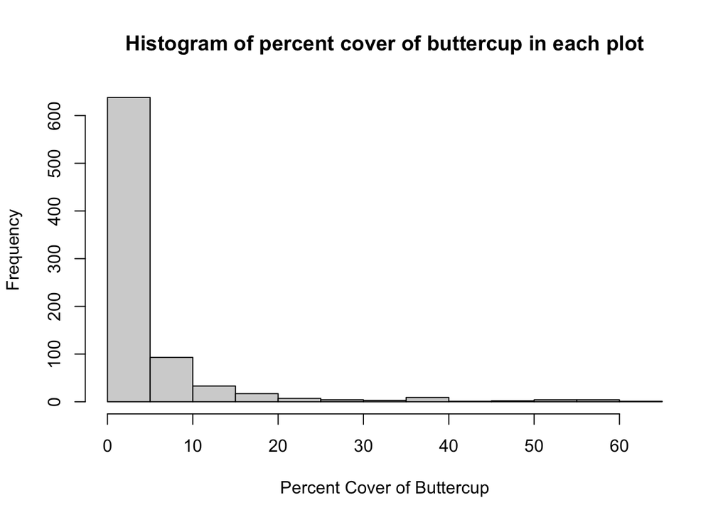

```r
hist(buttercup$Buttercuppc, main="Histogram of percent cover of buttercup in each plot", xlab="Percent Cover of Buttercup")
```

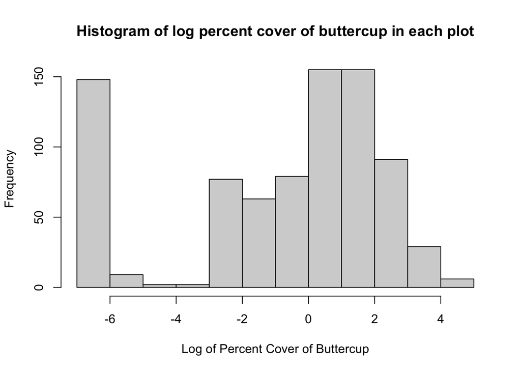

```r
#generating interaction terms
buttercup$buttercuppc_log <- log(buttercup$Buttercuppc+0.001)
hist(buttercup$buttercuppc_log, main="Histogram of log percent cover of buttercup in each plot", xlab = "Log of Percent Cover of Buttercup")
```

A histogram of percent cover of buttercup in each plot was used to show the important features. Since the responsible variable showed a highly skewed distribution, a log transformation was performed. If there were any 0 values and because log(0) is undefined, so 0.001 was added to each value of the Buttercuppc. Hence, another histogram of the log transformed Buttercuppc was plotted. From now on, the value of 0.001 added onto buttercuppc then log transformed will be referred to Buttercuppc or percent cover of buttercup. The histogram of log percent cover of buttercup in each plot is generated, which shows a more bell- shaped distribution.

# 3.

A simple analysis of variance model was fitted to the data including the interaction between Herbicide and Mow and a term for the Farm and Paddock.

```r
# A new variable is generated, which is the interaction between the Farm and Paddock variables.
farm_by_paddock <- interaction(buttercup$Farm, buttercup$Paddock)
fit1 <- aov(buttercuppc_log~Herbicide*Mow+farm_by_paddock, data=buttercup)
summary(fit1)
```

```
##                  Df Sum Sq Mean Sq F value Pr(>F)
## Herbicide         7   3517   502.5 130.611 <2e-16 ***
## Mow               1     15    15.2   3.954 0.0471 *
## farm_by_paddock  16   2086   130.4  33.882 <2e-16 ***
## Herbicide:Mow     7     41     5.8   1.510 0.1605
## Residuals       784   3016     3.8
## ---
## Signif. codes:  0 '***' 0.001 '**' 0.01 '*' 0.05 '.' 0.1 ' ' 1
```

```r
#coef(fit1)
#plot(fit1)
```

# 4.

Discuss the general conclusion:

The summary output of the ANOVA for the model including the interaction between Herbicide and Mow and interaction for the Farm and Paddock showed that Mow and Herbicide are both associated with percent cover of buttercup in each plot. The relationship we saw in the box plot earlier is also evident. The p-values of these variables were less than 0.05 (<2e-16 and 0.0471 for Herbicide and Mow respectively). But the p-value for Mow was very close to the significance level 0.05, which means the Mow fixed effect was not as statistically significant as the Herbicide fixed effect. Hence, Mow was not as strongly associated to percent cover of buttercup than Herbicide.

However, the p-value for Herbicide and Mow interaction (0.1605) was greater than 0.05. So, Herbicide and Mow interaction is not statistically significant. This suggested that whether a plot has been mown or not didn’t make a difference for the herbicides and what herbicide was used didn’t influence whether the plot was mown or not.

The p-value for Farm and Paddock interaction (<2e-16) was less than 0.05. So, the term is statistically significant. This suggested that the main effects, Farm and Paddock, would not be interpretable without considering the interaction effect between Farm and Paddock because whether the paddock was dry or wet depended on the farm. This also indicated that the relationship between Farm and percent cover of buttercup in each plot depended on whether the paddock was dry or wet.

# 5.

Fit a random effects model with the Farm by Paddock variable as the random effect and fixed effects for mowing and herbicides and their interaction in the model.

```r
library(lme4)
#is.factor(buttercup$Herbicide)
#is.factor(buttercup$Mow)
#levels(buttercup$Herbicide)
# Herbicide and Mow are factors and make the Nil control as the baseline
buttercup <- within(buttercup,Herbicide <- relevel(Herbicide,ref = "Nil"))
mod2 <-lmer(buttercup$buttercuppc_log~Herbicide*Mow+(1|farm_by_paddock),data=buttercup)
summary(mod2)
```

```
## Linear mixed model fit by REML ['lmerMod']
## Formula: buttercup$buttercuppc_log ~ Herbicide * Mow + (1 | farm_by_paddock)
##    Data: buttercup
##
## REML criterion at convergence: 3467.5
##
## Scaled residuals:
##     Min      1Q  Median      3Q     Max
## -3.8477 -0.4361  0.0828  0.6731  2.7870
##
## Random effects:
##  Groups          Name        Variance Std.Dev.
##  farm_by_paddock (Intercept) 2.636    1.623
##  Residual                    3.847    1.961
## Number of obs: 816, groups:  farm_by_paddock, 17
##
## Fixed effects:
##                                           Estimate Std. Error t value
## (Intercept)                                1.88384    0.48007   3.924
## HerbicideAminopyralid                     -5.53268    0.38842 -14.244
## HerbicideAminopyralid+triclopyr           -6.92618    0.38842 -17.832
## HerbicideFlumetsulam                      -3.49020    0.38842  -8.986
## HerbicideMCPA                             -2.76851    0.38842  -7.128
## HerbicideMCPB                             -1.29047    0.38842  -3.322
## HerbicideMCPB+bentazone                   -1.95517    0.38842  -5.034
## HerbicideThifensulfuron-methyl            -1.85809    0.38842  -4.784
## MowNo Mow                                  0.78486    0.38842   2.021
## HerbicideAminopyralid:MowNo Mow           -0.07921    0.54931  -0.144
## HerbicideAminopyralid+triclopyr:MowNo Mow  0.02754    0.54931   0.050
## HerbicideFlumetsulam:MowNo Mow            -0.92652    0.54931  -1.687
## HerbicideMCPA:MowNo Mow                   -0.72538    0.54931  -1.321
## HerbicideMCPB:MowNo Mow                   -0.31339    0.54931  -0.571
## HerbicideMCPB+bentazone:MowNo Mow         -0.89373    0.54931  -1.627
## HerbicideThifensulfuron-methyl:MowNo Mow  -1.18376    0.54931  -2.155
```

```
##
## Correlation matrix not shown by default, as p = 16 > 12.
## Use print(x, correlation=TRUE)  or
##     vcov(x)        if you need it
```

```r
#coef(mod2)
#plot(mod2)
```

The summary output of the random effects model suggested that the use of Herbicides decreased the percent cover of buttercup. This is shown by the estimate values being negative values (-5.53268, -6.92618, -3.49020, -2.76851, -1.29047, -1.95517 and -1.85809 for Aminopyralid, Aminopyralid+triclopyr, Flumetsulam, MCPA, MCPB, MCPB+bentazone and Thifensulfuron-methyl respectively). These values are compared to the base group, Nil control(No herbicide treatment used).

# 6.

1. i

1. ii

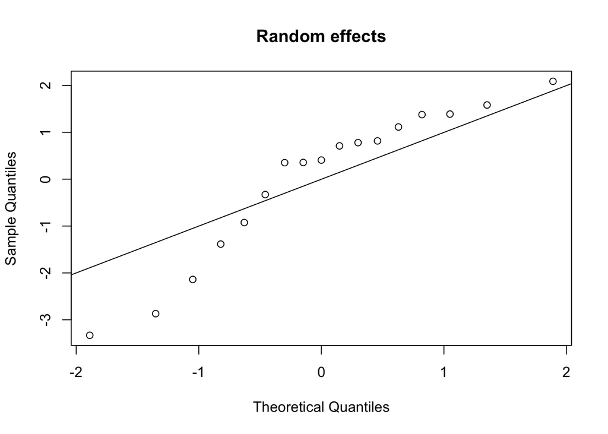

```r
#farm by paddock normal dist? - Q1/6b
qqnorm(ranef(mod2)$farm_by_paddock[[1]],main = 'Random effects')
abline(0,1)
```

```r
#hist(ranef(mod2)$farm_by_paddock[[1]],main = 'Random effects')
```

The Q-Q plot shows that the variability of the Farm by Paddock could be modelled by a normal distribution. Although the Q-Q plot does not show a perfectly normal distribution, the points are relatively close to the line.

# Question 2

# 1.

We have releveled tha predictors and we use the boxplot to look at the data and expect any effects in the data.

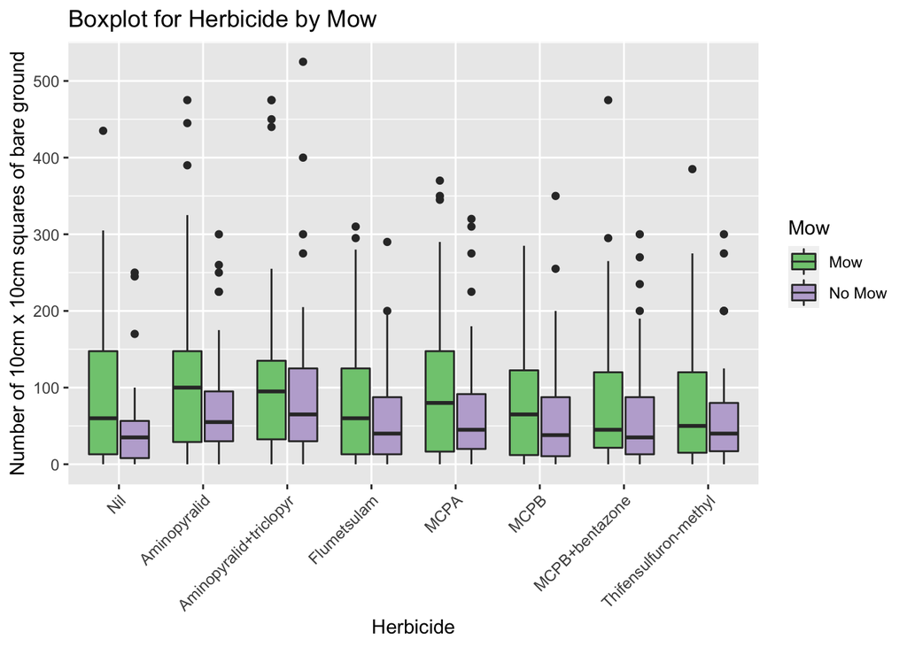

```r
#exploratory data analysis - boxplots
library(ggplot2)
library(RColorBrewer)

#boxplot for herbicide by mow
ggplot(buttercup, aes(x=Herbicide, y=BareGrnd, fill=Mow)) +
  geom_boxplot() +
  labs(title="Boxplot for Herbicide by Mow",x="Herbicide", y="Number of 10cm x 10cm squares of bare ground") +
  scale_fill_brewer(palette="Accent") +
  theme(text = element_text(size=11), axis.text.x = element_text(angle=45, hjust=1))
```

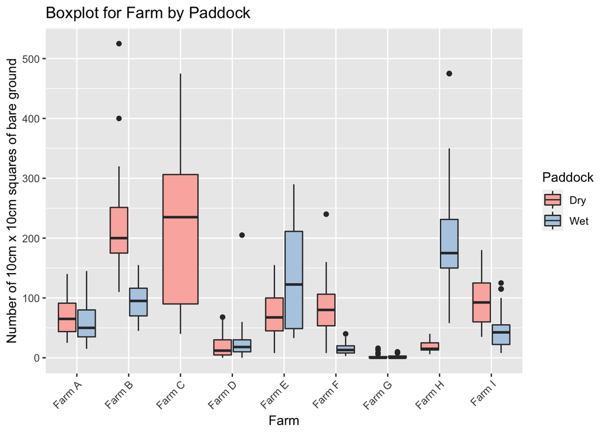

```r
#boxplot for farm by paddock
ggplot(buttercup, aes(x=Farm, y=BareGrnd, fill=Paddock)) +
  geom_boxplot() +
  labs(title="Boxplot for Farm by Paddock",x="Farm", y="Number of 10cm x 10cm squares of bare ground") +
  scale_fill_brewer(palette="Pastel1") +
  theme(text = element_text(size=11), axis.text.x = element_text(angle=45, hjust=1))
```

The boxplot showed that Farm C had the highest number of 10cm x 10cm squares of bare ground followed by Farm B. Farm G showed the lowest number of 10cm x 10cm squares of bare ground. Whether the paddock is dry or not does not seem to influence the number of squares of bare ground. There did not seem to be any obvious pattern for Farm by paddock effects. We would expect there is not much association between farm and paddock.

# 2.(a)

Look at the distribution of BareGrnd by showing the histogram. Justify the distribution used for the response variable.

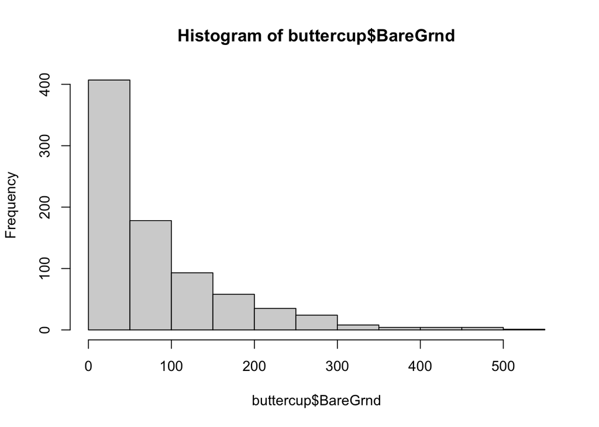

```r
#histogram of response variable
hist(buttercup$BareGrnd)
```

The histogram of the number of 10cm x 10cm squares of bare ground shows a poisson distribution.

The distribution for the response variable, BareGrnd, is poisson distribution. Poisson regression is a generalized linear model form of regression analysis used to model count data. Count data is a type of data which consists of non-negative integers. The response variable, BareGrnd, is the number of 10cm by 10cm squares of bare ground in each plot which is count data.

# 2.(b)

Fit the GLM and dicuss the result

```r
glm1<- glm(BareGrnd~Herbicide*Mow+farm_by_paddock, family="poisson",data=buttercup)
#summary(glm1) #better AIC 17515
glm1.1 <- glm(BareGrnd~Herbicide*Mow+farm_by_paddock, family="quasipoisson",data=buttercup)
summary(glm1.1)$coef[1:3,]
```

```
##                                  Estimate Std. Error   t value      Pr(>|t|)
## (Intercept)                     4.3345512 0.09432061 45.955506 1.189141e-224
## HerbicideAminopyralid           0.3009473 0.08330380  3.612648  3.224015e-04
## HerbicideAminopyralid+triclopyr 0.3250091 0.08288155  3.921369  9.575650e-05
```

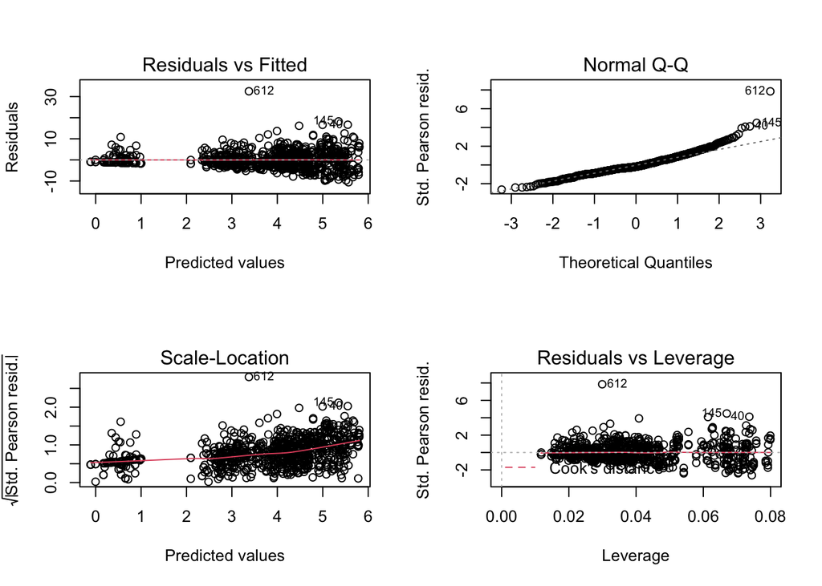

```r
#summary(glm1.1)
par(mfrow = c(2,2))
plot(glm1.1)
```

The summary output of the GLM including the fixed effects for both Mow and Herbicide, the interaction between them and interaction for the Farm and Paddock using poission distribution showed that the residual deviance was greater than the degrees of freedom (13124>784) Hence, the model is overdispersion and we need to fit the model by using quasipoisson. Note here, we have the better AIC is 17515.

As AIC could not be computed due to the GLM using quasipoisson, an estimate for R squared was calculated using 1 – (Residual deviance/Null deviance). The was calculated as 0.8089526 (=1-(13124/68695)). This suggested that the model explains around 81% of the variability of the number of squares of bare ground. This estimate suggests that the model fit is relatively good.

The summary output of the GLM refitted with quasipoisson shows that Aminopyralid+triclopyr and Aminopyralid are significantly better at increasing number of 10cm x 10cm squares of bare ground in each plot. Because their p-value are very small(3.224015e-04 and 9.575650e-05 for HerbicideAminopyralid and HerbicideAminopyralid+triclopyr respectively) and their estimate values being positive values(0.3009473 and 0.3250091 for HerbicideAminopyralid and HerbicideAminopyralid+triclopyr respectively).